# Adjacency-constrained hierarchical clustering of linkage disequilibrium

Pierre Neuvial, Shubham Chaturvedi

2017-08-26

In this short vignette we demonstrate the use of `adjClustBand_heap` function in the `adjclust` package to perform adjacency-constrained hierarchical clustering of Linkage Disequilibrium data.

```r
library("adjclust")
```

## Loading and displaying genotype data

The begining of this vignette closely follows the “LD vignette” of the SnpStats package [1]. First, we load genotype data.

```r
library("matrixStats")
library("snpStats")
data("ld.example", package="snpStats")
```

We focus on the `ceph.1mb` data. These data are drawn from the International HapMap Project and concern 603 SNPs over a 1Mb region of chromosome 22 in sample of 90 Europeans.

```r
ceph.1mb
```

```
## A SnpMatrix with  90 rows and  603 columns
## Row names:  NA06985 ... NA12892
## Col names:  rs5993821 ... rs5747302
```

We can compute and display the LD between these SNPs.

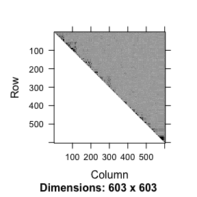

```r
ld.ceph <- ld(ceph.1mb, stats="R.squared", depth=p-1)
image(ld.ceph, lwd=0)
```

## Adjacency-constrained Hierarchical Agglomerative Clustering

The above figure suggests that the LD signal is concentrated close to the diagonal. Therefore, we focus on a diagonal band:

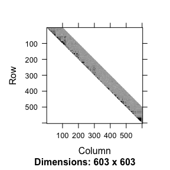

```r
h <- 100
ld.ceph <- ld(ceph.1mb, stats="R.squared", depth=h)
image(ld.ceph, lwd=0)
```

## Check data for presence of missing values or NaNs and eliminate them

```r
any(is.na(ld.ceph))
```

```
## [1] TRUE
```

```r
#which(is.na(ld.ceph), arr.ind = TRUE)

ceph.1mb[4,286]@.Data[1,1] <- as.raw(3)  ## to avoid NaNs
ld.ceph <- ld(ceph.1mb, stats="R.squared", depth=h)  ##calculate LD values again after NaN correction
ld.ceph <- round(ld.ceph, digits=10)  ## precision above 1e-10 is not required for this example
any(is.na(ld.ceph))
```

```
## [1] FALSE
```

```r
diag(ld.ceph) <- 1
```

```r
fit <- adjClustBand_heap(ld.ceph, "similarity", h, blMin=1)
```

This function implements the algorithm described in the third chapter of [2]. It is an extension of the algorithm described in [3]. The output is of class “hclust” a can be plotted as a dendrogram:

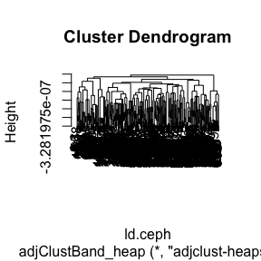

```r
plot(fit)
```

In particular, the output contains an element named `merge` which describes the successive merges of the clustering, and an element `gains` which gives the improvement in the criterion optimized by the clustering at each successive merge:

```r
head(cbind(fit$merge, fit$gains))
```

```
##      [,1] [,2] [,3]
## [1,]   -1   -2    0
## [2,] -255 -256    0
## [3,] -506 -507    0
## [4,] -492 -493    0
## [5,] -489 -490    0
## [6,] -487 -488    0
```

## References

[1] Clayton, D. (2015). snpStats: SnpMatrix and XSnpMatrix classes and methods. R package version 1.20.0

[2] Dehman A. (2015). [Spatial clustering of linkage disequilibrium blocks for genome-wide association studies](https://tel.archives-ouvertes.fr/tel-01288568/). Phd Thesis, Université Paris Saclay.

[3] Dehman, A. Ambroise, C. and Neuvial, P. (2015). Performance of a blockwise approach in variable selection using linkage disequilibrium information. *BMC Bioinformatics* 16:148.